# Example from Fox and Weisberg

Jacob Weverka

7/10/2020

Serially Correlated Errors

In time series data, errors from a regression model are unlikely to be independent

- assume that the process generating errors is stationary (need to figure out what this means)
- need to figure out this math in general

Using the gls Function

The `gls()` function is from the nlme package

```r
# install.packages("nlme")
# install.packages("car")
library(nlme)
library(tidyverse)
library(car)
```

Load some example data - Hartnagel - from the “car” package (Companion to Applied Regression)

year, 1931–1968.

- tfr, the total fertility rate, births per 1000 women-
- partic, women’s labor-force participation rate, per 1000.
- degrees, women’s post-secondary degree rate, per 10,000.
- fconvict, women’s indictable-offense conviction rate, per 100,000.
- ftheft, women’s theft conviction rate, per 100,000.
- mconvict, men’s indictable-offense conviction rate, per 100,000.
- mtheft, men’s theft conviction rate, per 100,000.

```r
head(Hartnagel)
```

```
##   year  tfr partic degrees fconvict ftheft mconvict mtheft
## 1 1931 3200    234    12.4     77.1     NA    778.7     NA
## 2 1932 3084    234    12.9     92.9     NA    745.7     NA
## 3 1933 2864    235    13.9     98.3     NA    768.3     NA
## 4 1934 2803    237    13.6     88.1     NA    733.6     NA
## 5 1935 2755    238    13.2     79.4   20.4    765.7  247.1
## 6 1936 2696    240    13.2     91.0   22.1    816.5  254.9
```

Here’s a first look on women’s conviction rates through time

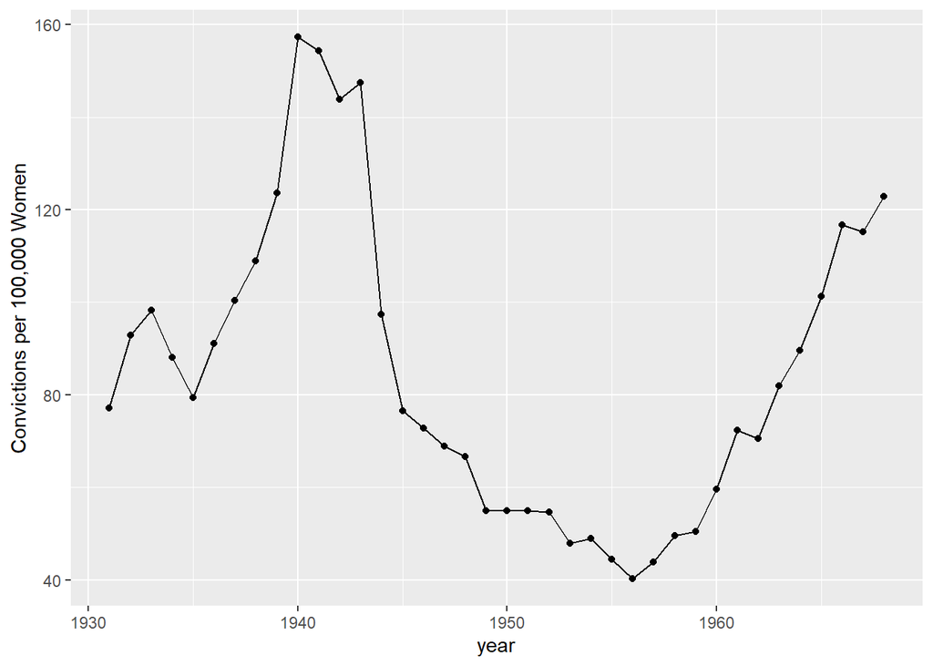

```r
p = ggplot(data = Hartnagel, aes(x = year, y = fconvict)) +
  geom_point() +
  geom_line() +
  ylab("Convictions per 100,000 Women")

p
```

Preliminary Ordinary Least Squares regression

```r
mod.ols = lm(fconvict ~ tfr + partic + degrees + mconvict, data = Hartnagel)
summary(mod.ols, correlation = TRUE)
```

```
##
## Call:
## lm(formula = fconvict ~ tfr + partic + degrees + mconvict, data = Hartnagel)
##
## Residuals:
##     Min      1Q  Median      3Q     Max
## -42.964  -9.204  -3.566   6.149  48.385
##
## Coefficients:
##               Estimate Std. Error t value Pr(>|t|)
## (Intercept) 127.639997  59.957044   2.129   0.0408 *
## tfr          -0.046567   0.008033  -5.797 1.75e-06 ***
## partic        0.253416   0.115132   2.201   0.0348 *
## degrees      -0.212049   0.211454  -1.003   0.3232
## mconvict      0.059105   0.045145   1.309   0.1995
## ---
## Signif. codes:  0 '***' 0.001 '**' 0.01 '*' 0.05 '.' 0.1 ' ' 1
##
## Residual standard error: 19.19 on 33 degrees of freedom
## Multiple R-squared:  0.6948, Adjusted R-squared:  0.6578
## F-statistic: 18.78 on 4 and 33 DF,  p-value: 3.905e-08
##
## Correlation of Coefficients:
##          (Intercept) tfr   partic degrees
## tfr      -0.79
## partic   -0.38        0.06
## degrees   0.05        0.10 -0.64
## mconvict -0.77        0.52 -0.16   0.23
```

According to the OLS regression, Womxn’s crime rate declines with fertility and increases with participation in the labor force

However, a graph of residuals shows that residuals may be autocorrelated:

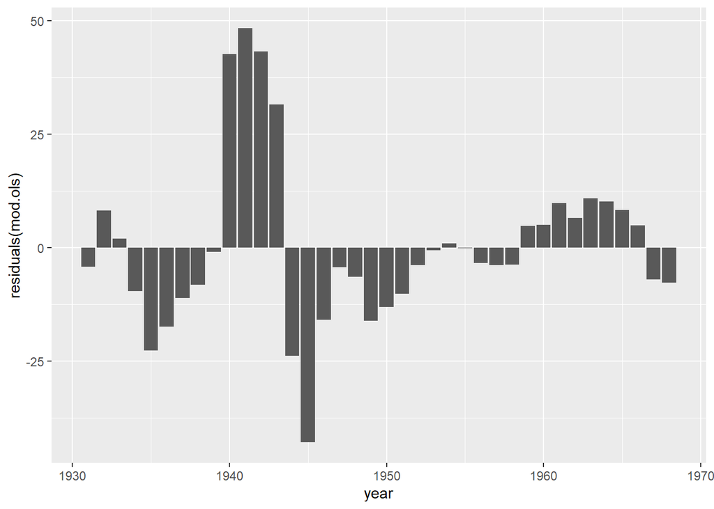

```r
q = ggplot(data = Hartnagel, aes(x = year, y = residuals(mod.ols))) +
  geom_col()

q
```

We can compute and plot the autocorrelation and partial autocorrelation functions of a time series using the `{r} acf()` function.

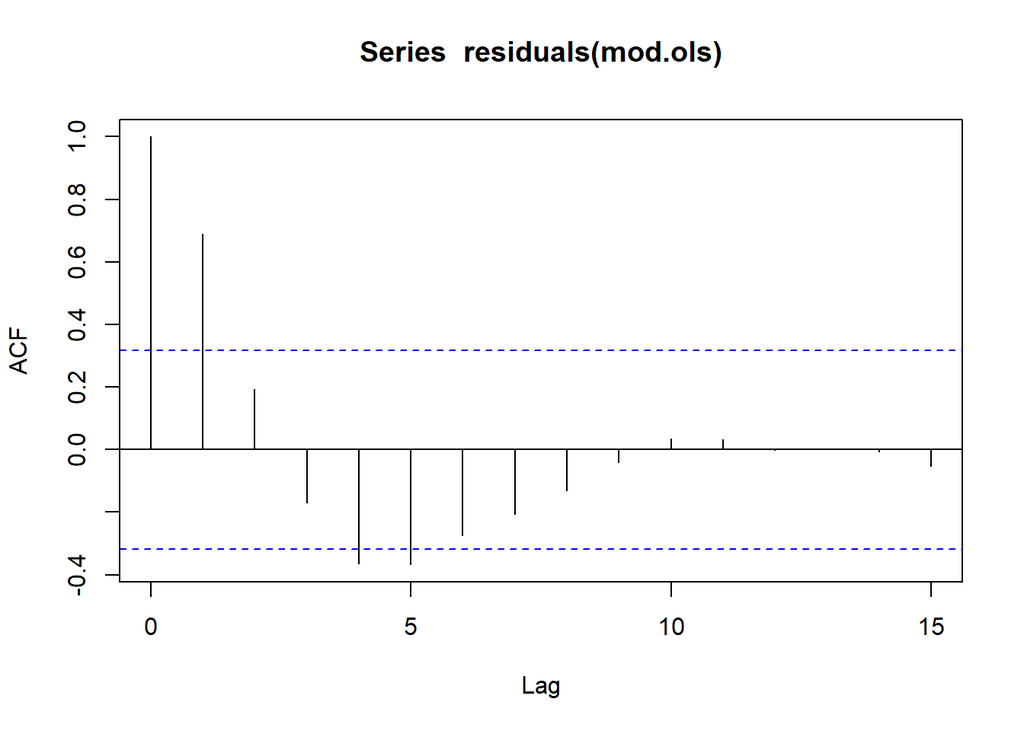

```r
acf(residuals(mod.ols))
```

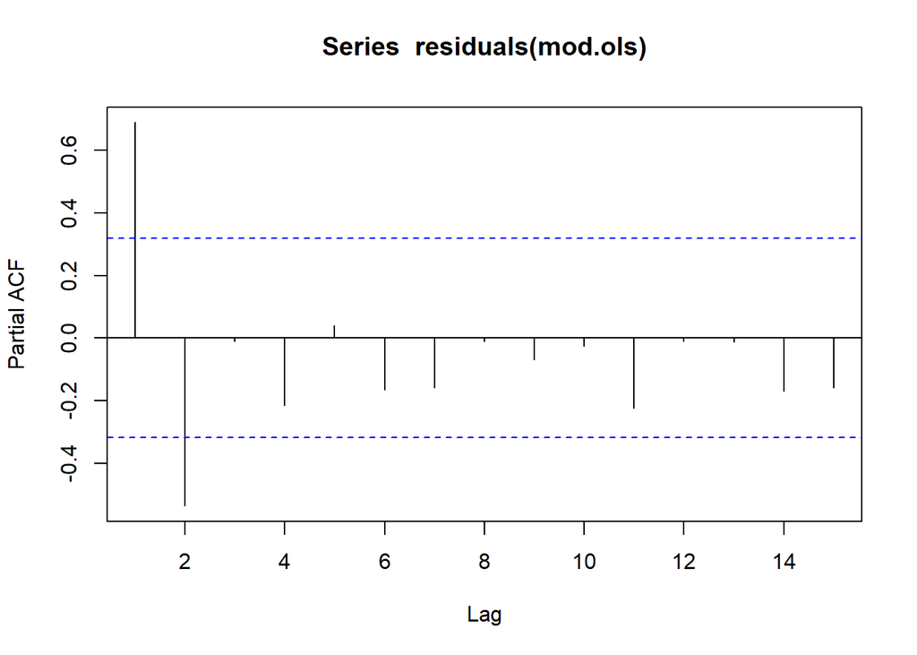

```r
acf(residuals(mod.ols), type = "partial")
```

We can follow this with the Durbin-Watson Test, which tests for autocorrelation

The function `{r} durbinWatsonTest()` calculates bootstrapped p-values. Alternatively, `{r} dwtest()` in the lmtest package conputes the p-value for the first order DW test analytically

```r
durbinWatsonTest(mod.ols, max.lag = 5)
```

```
##  lag Autocorrelation D-W Statistic p-value
##    1       0.6883450     0.6168636   0.000
##    2       0.1922665     1.5993563   0.128
##    3      -0.1685699     2.3187448   0.310
##    4      -0.3652775     2.6990538   0.012
##    5      -0.3673240     2.6521103   0.010
##  Alternative hypothesis: rho[lag] != 0
```

```r
lmtest::dwtest(mod.ols)
```

```
##
##  Durbin-Watson test
##
## data:  mod.ols
## DW = 0.61686, p-value = 6.96e-09
## alternative hypothesis: true autocorrelation is greater than 0
```

So there is autocorrelation in this model.

Using the gls() function:

```r
mod.gls = gls(fconvict ~ tfr + partic + degrees + mconvict, data = Hartnagel, correlation = corARMA(p = 2), method = "ML")

summary(mod.gls)
```

```
## Generalized least squares fit by maximum likelihood
##   Model: fconvict ~ tfr + partic + degrees + mconvict
##   Data: Hartnagel
##        AIC      BIC    logLik
##   305.4145 318.5152 -144.7073
##
## Correlation Structure: ARMA(2,0)
##  Formula: ~1
##  Parameter estimate(s):
##       Phi1       Phi2
##  1.0683473 -0.5507269
##
## Coefficients:
##                Value Std.Error   t-value p-value
## (Intercept) 83.34028  59.47084  1.401364  0.1704
## tfr         -0.03999   0.00928 -4.308632  0.0001
## partic       0.28761   0.11201  2.567653  0.0150
## degrees     -0.20984   0.20658 -1.015757  0.3171
## mconvict     0.07569   0.03501  2.161899  0.0380
##
##  Correlation:
##          (Intr) tfr    partic degres
## tfr      -0.773
## partic   -0.570  0.176
## degrees   0.093  0.033 -0.476
## mconvict -0.689  0.365  0.047  0.082
##
## Standardized residuals:
##        Min         Q1        Med         Q3        Max
## -2.4991516 -0.3716988 -0.1494540  0.3372409  2.9094711
##
## Residual standard error: 17.70228
## Degrees of freedom: 38 total; 33 residual
```

Here, the correlation structure is specified as an AR(2) process